# Sublime Text 4 Tips

J. R. Minter

Started: 2015-02-13, Last modified: 2021-05-24

Back to Index

These are John Minter’s tips for using the editor `Sublime Text 4`.

**Note** ST4 was released and I purchased on `2021-05-21`. This file needs more updates.

macOS setup

```
rm -rf /usr/local/bin/subl
ln -s "/Applications/SublimeText4.app/Contents/SharedSupport/bin/subl" /usr/local/bin/subl
```

# 1 Key info

A. Documentation

- [Main Page](https://www.sublimetext.com/blog/articles/sublime-text-4)
- [Documentation](https://www.sublimetext.com/docs/index.html)
- [docs.sublimetext.io](https://docs.sublimetext.io/)
- [The Book](https://sublimetextbook.com/)
- [Official](http://www.sublimetext.com/docs/3/) Documentation
- [Unofficial](https://sublime-text-unofficial-documentation.readthedocs.io/en/latest/) Documentation
- [Installing via Homebrew](https://www.code2bits.com/how-to-install-sublime-text-on-macos-using-homebrew/) using the [homebrew cask](https://github.com/Homebrew/homebrew-cask/blob/master/Casks/sublime-text.rb)
- [Package Control](https://packagecontrol.io/installation) (original…)
- [Stackoverflow Package Control](https://stackoverflow.com/questions/46651785/package-control-install-package-missing-in-sublime-text-3)
- [ST3](https://forum.sublimetext.com/t/package-control-not-working-at-all/29219) package control troubleshooting…

# 2 Revert to a freshly installed state

From [here](http://www.sublimetext.com/docs/3/revert.html)

Sublime Text can be reverted to a freshly installed state by removing your data folder. Depending on your operating system, this folder is located in:

- OS X: `~/Library/Application Support/Sublime Text 3`

  On MacOS, the key directory structure is shown here:

[figure not shown]

  ST3 Key Directory Structure. The license file goes in `Local`, The settings go in `Packages/User` (see the red arrows).

- Windows: `%APPDATA%\Sublime Text 3`
- Linux: `~/.config/sublime-text-3`

To revert to a freshly installed state, you can:

1. Exit Sublime Text
2. Move the data folder to a backup location
3. Start Sublime Text

To make sure Package Control works

1. Open the User settings
2. Make certain `PackageControl` is **not** in the excluded packages. *Only* `Vintage` should be in the list…

# 3 Custom python build systems

## 3.1 Macbook Pro

**Note**: There is a better way [here](https://docs.anaconda.com/anaconda/user-guide/tasks/integration/sublime/).

I wanted to create a sublime text 3 build system for Anaconda with Python 3.7

I created a file named `python37.sublime-build` in the folder

```
/Users/jrminter/Library/Application Support/Sublime Text 3/Packages/User
```

The content of the `python37.sublime` file:

```
{
 "cmd": ["/Users/jrminter/miniconda3/bin/python", "-u", "$file"],
 "file_regex": "^[ ]File \"(...?)\", line ([0-9]*)",
 "selector": "source.python"
}
```

# 4 Better Markdown

From [Marius Schulz](https://blog.mariusschulz.com/2014/12/16/how-to-set-up-sublime-text-for-a-vastly-better-markdown-writing-experience)

1. Install the `Monokai Extended` package.
2. Install the `Markdown Editing` package to get the additional control

**I really struggled with this…**

The solution was to set the:

`Preferences > Package Settings > Markdown-Editing > Markdown GFM Settings-User`

to:

```
{
    "draw_centered": false,
    "line_numbers": true,
    "color_scheme": "Packages/Color Scheme - Default/Monokai.sublime-color-scheme",
    "extensions":
    [
        ".Rmd",
        ".md",
    ]
}
```

and repeat for:

`Preferences > Package Settings > Markdown-Editing > Markdown (Standard) Settings-User`

and

`Preferences > Package Settings > Markdown-Editing > MultiMarkdown Settings-User`

to the same values.

Note as of 2019-05-07, the installed packages on my Win7 box are:

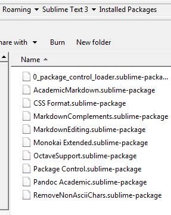

# 5 Spell Checking

One can set the dictionary from the `View` menu. One can toggle spell checking either from the `View` menu or with `F6`. For more information, see [here](https://www.sublimetext.com/docs/3/spell_checking.html).

# 6 Setting file associations

From [StackOverflow](http://stackoverflow.com/questions/7574502/set-default-syntax-to-different-filetype-in-sublime-text-2)

In the current version of Sublime Text 2 and 3 you can set the syntax for all files of a certain file extension using an option in the menu bar. Open a file with the extension you want to set a default for and navigate through the following menus:

`View -> Syntax -> Open all with current extension as... ->[your syntax choice].`

# 7 The Package Control add-in

I use the following add ins:

  First, install Package Control

  In Sublime Text, open the Command Palette (Cmd-Shift-P on Mac, Ctrl-Shift-P on Linux/Windows) and choose `Package Control: Add Repository`

  Add `https://github.com/apjanke/OctaveSupport`

  Open the Command Palette and choose `Package Control: Install Package` Select OctaveSupport from the package list

# 8 My current preferences

## 8.1 Default

```
{
    // Sets the colors used within the text area
    "color_scheme": "Monokai.sublime-color-scheme",

    // Note that the font_face and font_size are overridden in the platform
    // specific settings file. Set them in your User File Preferences.
    "font_face": "",
    "font_size": 10,

    "font_options": [],
    "theme_font_options": [],

    // Characters that are considered to separate words
    "word_separators": "./\\()\"'-:,.;<>~!@#$%^&*|+=[]{}`~?",

    // Set to false to prevent line numbers being drawn in the gutter
    "line_numbers": true,

    // Set to false to hide the gutter altogether
    "gutter": true,

    // Spacing between the gutter and the text
    "margin": 4,

    // Fold buttons are the triangles shown in the gutter to fold regions of text
    "fold_buttons": true,

    // Hides the fold buttons unless the mouse is over the gutter
    "fade_fold_buttons": true,

    // Columns in which to display vertical rulers
    "rulers": [],

    // Set to true to turn spell checking on by default
    "spell_check": false,

    // The number of spaces a tab is considered equal to
    "tab_size": 4,

    // Set to true to insert spaces when tab is pressed
```

[output cut: 313 more lines]

```
    // their symbols. This is required for Goto Definition to work.
    "index_files": true,

    // Set the number threads to use for indexing. A value of 0 will make
    // Sublime Text guess based on the number of cores. Use the index_files
    // setting to disable all workers.
    "index_workers": 0,

    // index_exclude_patterns indicate which files won't be indexed.
    "index_exclude_patterns": ["*.log"],

    // List any packages to ignore here. When removing entries from this list,
    // a restart may be required if the package contains plugins.
    "ignored_packages": ["Vintage"]
}
```

## 8.2 User defaults

```
{
    "added_words":
    [
        "maxima",
        "binarize",
        "Northgate",
        "metallographic",
        "microscopist",
        "micrographs",
        "micrograph",
        "nanoparticles",
        "ultrathin",
        "chemometrics"
    ],
    "color_scheme": "Packages/Color Scheme - Default/Monokai.tmTheme",
    "dictionary": "Packages/Language - English/en_US.dic",
    "draw_white_space": "all",
    "font_face": "Lucida Console",
    "font_size": 12,
    "hot_exit": true,
    "ignored_packages":
    [
        "Vintage",
    ],
    "ignored_words":
    [
        "Lispix",
        "hexane",
        "nanoparticles",
        "toolbar",
        "ultrathin"
    ],
    "numix_folder_icons": true,
    "remember_open_files": true,
    "rulers":
    [
        72
    ],
    "tab_size": 2,
    "tabs_large": true,
    "theme": "Numix Dark.sublime-theme",
    "translate_tabs_to_spaces": false
}
```

On Windows, this is in file `Preferences.sublime-settings` in:

```
C:\Users\jrminter\AppData\Roaming\Sublime Text 3\Packages\User
```

On Mac this is in:

```
"/Users/jrminter/Library/Application Support/Sublime Text 3/Packages/User"
```

## 8.3 Packages

Available packages are cataloged on [packagecontrol.io](https://packagecontrol.io/).

# 9 Using Sublime Text 3 with git

## 9.1 Windows

From [Stack Overflow](http://stackoverflow.com/questions/8951275/git-config-core-editor-how-to-make-sublime-text-the-default-editor-for-git-on)

> Sublime Text 3 (Build 3065)

> Sublime Text 3 (Build 3065) added the subl.exe command line helper. Use `subl.exe -h` for the options available to you. I have `"hot_exit": true` and `"remember_open_files": true` set in my Sublime Text user settings. I have found the following to git config to work well for me.

```
git config --global core.editor "'c:/program files/sublime text 3/subl.exe' -w"
```

> With this git config the a new tab is opened in my editor. I edit my commit message, save the tab and close it (`CTRL+w`). Git will wait until the tab is closed to continue its work.

## 9.2 MacOSX

See the [Git Hub](https://help.github.com/articles/associating-text-editors-with-git/) page

Need to test the Windows approach. Need to see where subl is, perhaps symlink to `/usr/local/bin`

Back to Index